# A3: SPL Library Checkouts

### Introduction

I have chosen to analyze the trends in the checkout patterns of cooking books over time. I selected this topic because borrowing cookbooks is a different experience than borrowing books for leisurely reading. People often borrow cooking books to learn new recipes and techniques, and I am interested in exploring this trend, especially in light of the fact that recipes are now readily available online

### The Dataset

The Seattle Public Library was responsible for collecting and publishing the data, which includes information on the number of physical and electronic book checkouts from 2005 to the present day. The data is broken down by year and month and includes specific titles and authors. The library’s system recorded checkouts and returns of library materials, while electronic book checkouts were tracked through the library’s digital lending platform.

The data was primarily collected for internal library use to inform collection development decisions and to evaluate the popularity of particular subject areas. Additionally, it was made available to data scientists and other interested parties. When working with library data, it is essential to consider ethical considerations, such as protecting patron privacy and ensuring that personally identifiable information is not shared or made public.

However, one limitation of the data is that it only represents checkouts from the Seattle Public Library and may not reflect checkouts from other libraries or bookstores in the region. Furthermore, the data does not provide insights into why people checked out certain books, which may limit the analysis. Finally, changes in library policies, such as borrowing limits or the availability of certain titles, could affect checkout trends over time, influencing the accuracy of the data.

Overall, the data offers valuable insights into the popularity of specific books and subject areas over time, but it is necessary to consider the limitations and potential biases in the data when drawing conclusions.

### Number of Ebooks checked out vs the number of physical cooking books checked out

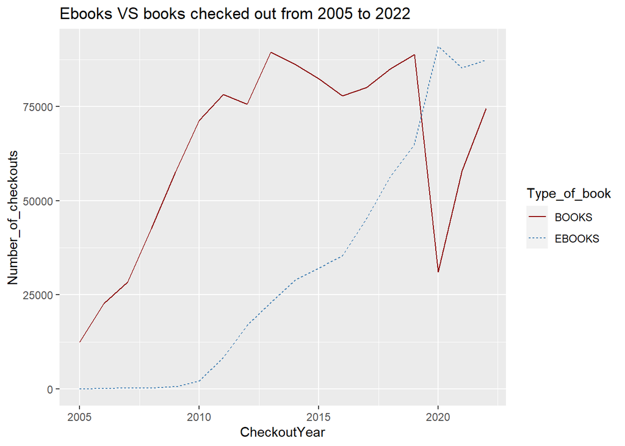

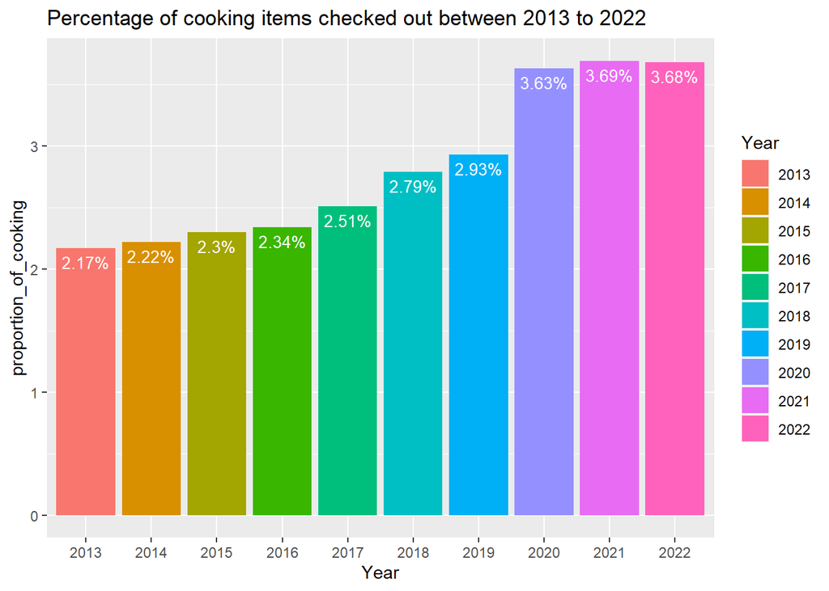

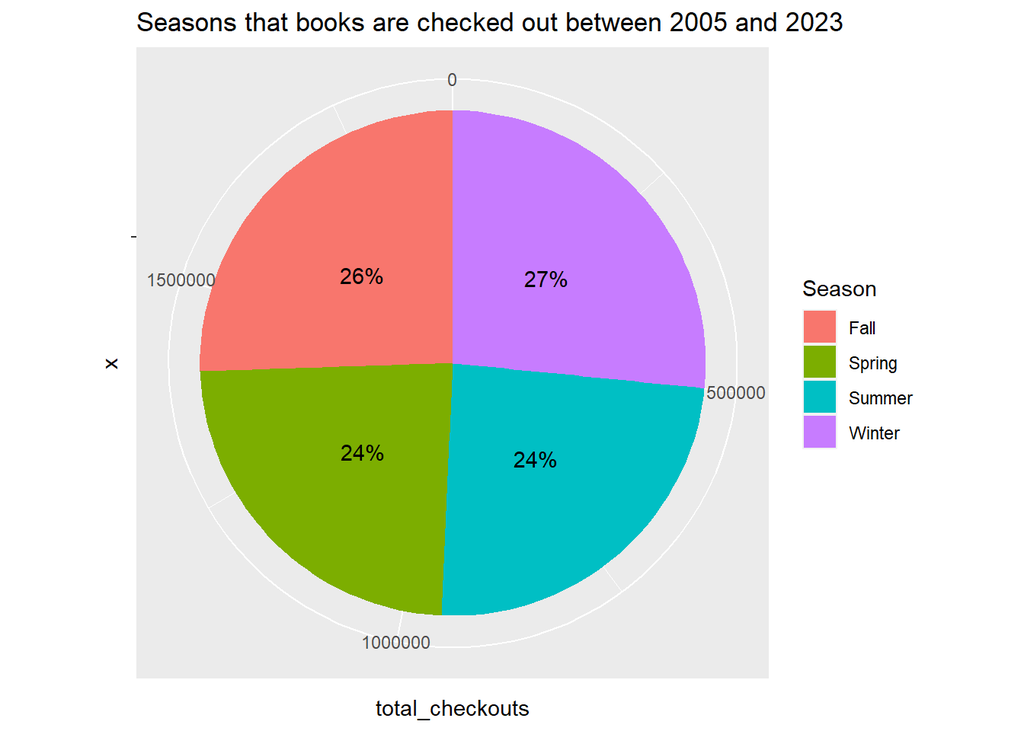

This chart presents the seasonal trends of cooking book checkouts from 2005. Approximately 24% of cooking books were checked out during the spring and summer months, while 26% were checked out in the fall and 27% were checked out during winter. These findings align with expectations, as fall and winter seasons coincide with major holidays such as Thanksgiving and Christmas when people may be more interested in cooking and baking